# defect_prediction_analysis

```python
pip install pandas numpy matplotlib seaborn scikit-learn xgboost shap imbalanced-learn
```

```python
import warnings
warnings.filterwarnings("ignore")

# Libraries to help with reading and manipulating data
import pandas as pd
import numpy as np
# Libraries to help with data visualization
import matplotlib.pyplot as plt
import seaborn as sns

from sklearn.model_selection import train_test_split
from sklearn.preprocessing import StandardScaler

from sklearn.linear_model import LogisticRegression
from sklearn.ensemble import RandomForestClassifier
from xgboost import XGBClassifier

from sklearn.metrics import (
    accuracy_score,
    precision_score,
    recall_score,
    f1_score,
    roc_auc_score,
    confusion_matrix,
    classification_report,
    roc_curve
)

from imblearn.over_sampling import SMOTE

import shap
```

```python
# Run the following line if using Google Colab
from google.colab import drive
drive.mount('/content/drive')
```

```python
# ---- Configure dataset path ----
DATA_PATH = '/content/drive/MyDrive/MS in AL ML Walsh/Capstone/kc1.csv'
```

```python
import pandas as pd

# Load dataset
df = pd.read_csv(DATA_PATH)

# View first 5 rows
df.head()
```

|  | loc | v(g) | ev(g) | iv(g) | n | v | l | d | i | e | ... | lOCode | lOComment | lOBlank | locCodeAndComment | uniq_Op | uniq_Opnd | total_Op | total_Opnd | branchCount | defects |
| --- | --- | --- | --- | --- | --- | --- | --- | --- | --- | --- | --- | --- | --- | --- | --- | --- | --- | --- | --- | --- | --- |
| 0 | 1.1 | 1.4 | 1.4 | 1.4 | 1.3 | 1.30 | 1.30 | 1.30 | 1.30 | 1.30 | ... | 2 | 2 | 2 | 2 | 1.2 | 1.2 | 1.2 | 1.2 | 1.4 | False |
| 1 | 1.0 | 1.0 | 1.0 | 1.0 | 1.0 | 1.00 | 1.00 | 1.00 | 1.00 | 1.00 | ... | 1 | 1 | 1 | 1 | 1.0 | 1.0 | 1.0 | 1.0 | 1.0 | True |
| 2 | 83.0 | 11.0 | 1.0 | 11.0 | 171.0 | 927.89 | 0.04 | 23.04 | 40.27 | 21378.61 | ... | 65 | 10 | 6 | 0 | 18.0 | 25.0 | 107.0 | 64.0 | 21.0 | True |
| 3 | 46.0 | 8.0 | 6.0 | 8.0 | 141.0 | 769.78 | 0.07 | 14.86 | 51.81 | 11436.73 | ... | 37 | 2 | 5 | 0 | 16.0 | 28.0 | 89.0 | 52.0 | 15.0 | True |
| 4 | 25.0 | 3.0 | 1.0 | 3.0 | 58.0 | 254.75 | 0.11 | 9.35 | 27.25 | 2381.95 | ... | 21 | 0 | 2 | 0 | 11.0 | 10.0 | 41.0 | 17.0 | 5.0 | True |

5 rows × 22 columns

```python
# Dataset shape
df.shape
```

```
(2109, 22)
```

```python
# Column names
df.columns
```

```
Index(['loc', 'v(g)', 'ev(g)', 'iv(g)', 'n', 'v', 'l', 'd', 'i', 'e', 'b', 't',
       'lOCode', 'lOComment', 'lOBlank', 'locCodeAndComment', 'uniq_Op',
       'uniq_Opnd', 'total_Op', 'total_Opnd', 'branchCount', 'defects'],
      dtype='object')
```

```python
# Data types
df.info()
```

```
<class 'pandas.core.frame.DataFrame'>
RangeIndex: 2109 entries, 0 to 2108
Data columns (total 22 columns):
 #   Column             Non-Null Count  Dtype
---  ------             --------------  -----
 0   loc                2109 non-null   float64
 1   v(g)               2109 non-null   float64
 2   ev(g)              2109 non-null   float64
 3   iv(g)              2109 non-null   float64
 4   n                  2109 non-null   float64
 5   v                  2109 non-null   float64
 6   l                  2109 non-null   float64
 7   d                  2109 non-null   float64
 8   i                  2109 non-null   float64
 9   e                  2109 non-null   float64
 10  b                  2109 non-null   float64
 11  t                  2109 non-null   float64
 12  lOCode             2109 non-null   int64
 13  lOComment          2109 non-null   int64
 14  lOBlank            2109 non-null   int64
 15  locCodeAndComment  2109 non-null   int64
 16  uniq_Op            2109 non-null   float64
 17  uniq_Opnd          2109 non-null   float64
 18  total_Op           2109 non-null   float64
 19  total_Opnd         2109 non-null   float64
 20  branchCount        2109 non-null   float64
 21  defects            2109 non-null   bool
dtypes: bool(1), float64(17), int64(4)
memory usage: 348.2 KB
```

```python
df.nunique().sort_values()
```

|  | 0 |
| --- | --- |
| defects | 2 |
| locCodeAndComment | 12 |
| ev(g) | 21 |
| iv(g) | 26 |
| lOComment | 28 |
| v(g) | 31 |
| lOBlank | 31 |
| uniq_Op | 34 |
| branchCount | 44 |
| l | 52 |
| uniq_Opnd | 73 |
| b | 92 |
| lOCode | 121 |
| loc | 139 |
| total_Opnd | 153 |
| total_Op | 207 |
| n | 278 |
| d | 548 |
| v | 729 |
| i | 893 |
| t | 947 |
| e | 961 |

**dtype:** int64

```python
# Summary statistics
df.describe().T
```

|  | count | mean | std | min | 25% | 50% | 75% | max |
| --- | --- | --- | --- | --- | --- | --- | --- | --- |
| loc | 2109.0 | 20.372262 | 29.754442 | 1.0 | 3.00 | 9.00 | 24.00 | 288.00 |
| v(g) | 2109.0 | 2.838028 | 3.900763 | 1.0 | 1.00 | 1.00 | 3.00 | 45.00 |
| ev(g) | 2109.0 | 1.674443 | 2.200659 | 1.0 | 1.00 | 1.00 | 1.00 | 26.00 |
| iv(g) | 2109.0 | 2.546420 | 3.375859 | 1.0 | 1.00 | 1.00 | 3.00 | 45.00 |
| n | 2109.0 | 49.829445 | 83.599874 | 0.0 | 4.00 | 16.00 | 58.00 | 1106.00 |
| v | 2109.0 | 258.696719 | 516.317605 | 0.0 | 8.00 | 57.06 | 265.93 | 7918.82 |
| l | 2109.0 | 0.319583 | 0.317029 | 0.0 | 0.08 | 0.20 | 0.67 | 2.00 |
| d | 2109.0 | 6.771242 | 7.863646 | 0.0 | 1.50 | 3.50 | 9.20 | 53.75 |
| i | 2109.0 | 21.240071 | 21.500367 | 0.0 | 5.33 | 14.40 | 29.85 | 193.06 |
| e | 2109.0 | 5242.386240 | 17444.981211 | 0.0 | 12.00 | 213.97 | 2276.02 | 324803.51 |
| b | 2109.0 | 0.086738 | 0.175507 | 0.0 | 0.00 | 0.02 | 0.09 | 2.64 |
| t | 2109.0 | 291.245040 | 969.165160 | 0.0 | 0.67 | 11.89 | 126.45 | 18044.64 |
| lOCode | 2109.0 | 14.525367 | 24.188302 | 0.0 | 0.00 | 5.00 | 17.00 | 262.00 |
| lOComment | 2109.0 | 0.945946 | 3.085271 | 0.0 | 0.00 | 0.00 | 0.00 | 44.00 |
| lOBlank | 2109.0 | 1.759602 | 3.856850 | 0.0 | 0.00 | 0.00 | 2.00 | 58.00 |
| locCodeAndComment | 2109.0 | 0.132764 | 0.704023 | 0.0 | 0.00 | 0.00 | 0.00 | 12.00 |
| uniq_Op | 2109.0 | 7.631674 | 5.730347 | 0.0 | 3.00 | 6.00 | 11.00 | 37.00 |
| uniq_Opnd | 2109.0 | 9.537316 | 12.195727 | 0.0 | 1.00 | 5.00 | 13.00 | 120.00 |
| total_Op | 2109.0 | 31.043717 | 51.776056 | 0.0 | 3.00 | 10.00 | 36.00 | 678.00 |
| total_Opnd | 2109.0 | 18.786724 | 32.074398 | 0.0 | 1.00 | 6.00 | 22.00 | 428.00 |
| branchCount | 2109.0 | 4.665908 | 7.792206 | 1.0 | 1.00 | 1.00 | 5.00 | 89.00 |

## Data Preprocessing

### Checking for missing values

```python
# checking for missing values
df.isnull().sum()
```

|  | 0 |
| --- | --- |
| loc | 0 |
| v(g) | 0 |
| ev(g) | 0 |
| iv(g) | 0 |
| n | 0 |
| v | 0 |
| l | 0 |
| d | 0 |
| i | 0 |
| e | 0 |
| b | 0 |
| t | 0 |
| lOCode | 0 |
| lOComment | 0 |
| lOBlank | 0 |
| locCodeAndComment | 0 |
| uniq_Op | 0 |
| uniq_Opnd | 0 |
| total_Op | 0 |
| total_Opnd | 0 |
| branchCount | 0 |
| defects | 0 |

**dtype:** int64

- There are no missing values so no need to treat any missing data.

```python
df.groupby('defects').size()
```

| defects | 0 |
| --- | --- |
| False | 1783 |
| True | 326 |

**dtype:** int64

```python
df["defects"].value_counts()
```

| defects | count |
| --- | --- |
| False | 1783 |
| True | 326 |

**dtype:** int64

### Checking for duplicate values

```python
df.duplicated().sum()
```

```
np.int64(897)
```

- There are 897 duplicate rows in the dataset.

```python
duplicate_rows = df[df.duplicated()]
duplicate_rows.head()
```

|  | loc | v(g) | ev(g) | iv(g) | n | v | l | d | i | e | ... | lOCode | lOComment | lOBlank | locCodeAndComment | uniq_Op | uniq_Opnd | total_Op | total_Opnd | branchCount | defects |
| --- | --- | --- | --- | --- | --- | --- | --- | --- | --- | --- | --- | --- | --- | --- | --- | --- | --- | --- | --- | --- | --- |
| 92 | 4.0 | 1.0 | 1.0 | 1.0 | 4.0 | 8.00 | 0.67 | 1.50 | 5.33 | 12.00 | ... | 2 | 0 | 0 | 0 | 3.0 | 1.0 | 3.0 | 1.0 | 1.0 | True |
| 150 | 4.0 | 1.0 | 1.0 | 1.0 | 4.0 | 8.00 | 0.67 | 1.50 | 5.33 | 12.00 | ... | 2 | 0 | 0 | 0 | 3.0 | 1.0 | 3.0 | 1.0 | 1.0 | True |
| 185 | 17.0 | 4.0 | 3.0 | 3.0 | 32.0 | 125.02 | 0.12 | 8.25 | 15.15 | 1031.42 | ... | 15 | 0 | 0 | 0 | 9.0 | 6.0 | 21.0 | 11.0 | 7.0 | True |
| 188 | 3.0 | 1.0 | 1.0 | 1.0 | 1.0 | 0.00 | 0.00 | 0.00 | 0.00 | 0.00 | ... | 1 | 0 | 0 | 0 | 1.0 | 0.0 | 1.0 | 0.0 | 1.0 | True |
| 200 | 4.0 | 1.0 | 1.0 | 1.0 | 4.0 | 8.00 | 0.67 | 1.50 | 5.33 | 12.00 | ... | 2 | 0 | 0 | 0 | 3.0 | 1.0 | 3.0 | 1.0 | 1.0 | True |

5 rows × 22 columns

```python
duplicate_rows["defects"].value_counts()
```

| defects | count |
| --- | --- |
| False | 886 |
| True | 11 |

**dtype:** int64

```python
df.groupby(df.columns.tolist()).size().sort_values(ascending=False).head(10)
```

| loc | v(g) | ev(g) | iv(g) | n | v | l | d | i | e | b | t | lOCode | lOComment | lOBlank | locCodeAndComment | uniq_Op | uniq_Opnd | total_Op | total_Opnd | branchCount | defects | 0 |
| --- | --- | --- | --- | --- | --- | --- | --- | --- | --- | --- | --- | --- | --- | --- | --- | --- | --- | --- | --- | --- | --- | --- |
| 2.0 | 1.0 | 1.0 | 1.0 | 4.0 | 8.00 | 0.67 | 1.5 | 5.33 | 12.00 | 0.00 | 0.67 | 0 | 0 | 0 | 0 | 3.0 | 1.0 | 3.0 | 1.0 | 1.0 | False | 112 |
| 1.0 | 1.0 | 1.0 | 1.0 | 4.0 | 8.00 | 0.67 | 1.5 | 5.33 | 12.00 | 0.00 | 0.67 | 0 | 0 | 0 | 0 | 3.0 | 1.0 | 3.0 | 1.0 | 1.0 | False | 104 |
| 3.0 | 1.0 | 1.0 | 1.0 | 1.0 | 0.00 | 0.00 | 0.0 | 0.00 | 0.00 | 0.00 | 0.00 | 1 | 0 | 0 | 0 | 1.0 | 0.0 | 1.0 | 0.0 | 1.0 | False | 71 |
| 4.0 | 1.0 | 1.0 | 1.0 | 4.0 | 8.00 | 0.67 | 1.5 | 5.33 | 12.00 | 0.00 | 0.67 | 2 | 0 | 0 | 0 | 3.0 | 1.0 | 3.0 | 1.0 | 1.0 | False | 55 |
| 2.0 | 1.0 | 1.0 | 1.0 | 5.0 | 11.61 | 0.67 | 1.5 | 7.74 | 17.41 | 0.00 | 0.97 | 0 | 0 | 0 | 0 | 3.0 | 2.0 | 3.0 | 2.0 | 1.0 | False | 50 |
| 4.0 | 1.0 | 1.0 | 1.0 | 4.0 | 8.00 | 0.67 | 1.5 | 5.33 | 12.00 | 0.00 | 0.67 | 0 | 0 | 0 | 0 | 3.0 | 1.0 | 3.0 | 1.0 | 1.0 | False | 31 |
| 2.0 | 1.0 | 1.0 | 1.0 | 3.0 | 4.75 | 1.00 | 1.0 | 4.75 | 4.75 | 0.00 | 0.26 | 0 | 0 | 0 | 0 | 2.0 | 1.0 | 2.0 | 1.0 | 1.0 | False | 21 |
| 4.0 | 1.0 | 1.0 | 1.0 | 3.0 | 4.75 | 1.00 | 1.0 | 4.75 | 4.75 | 0.00 | 0.26 | 0 | 0 | 0 | 0 | 2.0 | 1.0 | 2.0 | 1.0 | 1.0 | False | 20 |
|  |  |  |  | 5.0 | 11.61 | 0.50 | 2.0 | 5.80 | 23.22 | 0.00 | 1.29 | 2 | 0 | 0 | 0 | 4.0 | 1.0 | 4.0 | 1.0 | 1.0 | False | 19 |
|  |  |  |  | 7.0 | 19.65 | 0.40 | 2.5 | 7.86 | 49.13 | 0.01 | 2.73 | 2 | 0 | 0 | 0 | 5.0 | 2.0 | 5.0 | 2.0 | 1.0 | False | 17 |

**dtype:** int64

```python
print("Missing Values:", df.isnull().sum().sum())
print("Duplicate Rows:", df.duplicated().sum())
print("Shape:", df.shape)
```

```
Missing Values: 0
Duplicate Rows: 897
Shape: (2109, 22)
```

- From above output we can see that one duplicate rows occur 50+ or even 100+ times
- They are not data entry errors; they represent different software modules with identical metric values.
- Duplicate records were retained because they represent valid software modules
- with identical software metrics in the original NASA PROMISE KC1 dataset.
- Removing them could distort the original data distribution.
- The NASA PROMISE KC1 dataset is commonly used this way in software defect prediction research.

# EDA

### Target Class Distribution

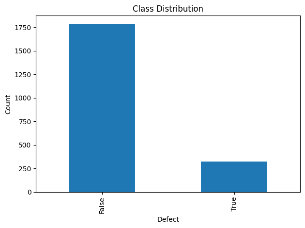

```python
import os

df["defects"].value_counts().plot(kind="bar")
plt.title("Class Distribution")
plt.xlabel("Defect")
plt.ylabel("Count")
plt.tight_layout()

# Create the directory if it doesn't exist
output_dir = "/content/drive/MyDrive/MS in AL ML Walsh/Capstone/Figures"
os.makedirs(output_dir, exist_ok=True)

plt.savefig(os.path.join(output_dir, "class_distribution.png"), dpi=300)
plt.show()
```

### Histogram

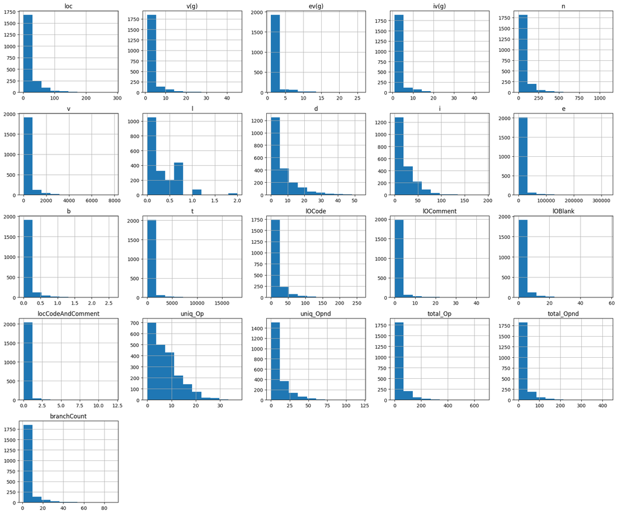

```python
df.hist(figsize=(18,15))
plt.tight_layout()
plt.savefig(os.path.join(output_dir, "histograms.png"), dpi=300)
#plt.savefig(output_dir/histograms.png", dpi=300)
plt.show()
```

### Correlation Matrix

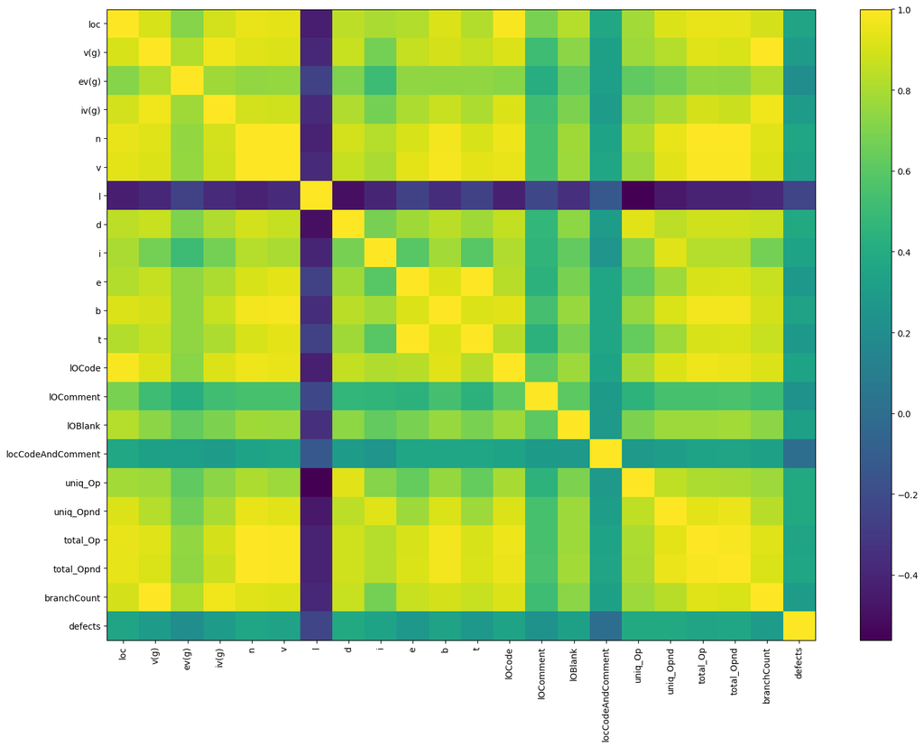

```python
plt.figure(figsize=(16,12))
corr = df.corr(numeric_only=True)
plt.imshow(corr, aspect="auto")
plt.colorbar()
plt.xticks(range(len(corr.columns)), corr.columns, rotation=90)
plt.yticks(range(len(corr.columns)), corr.columns)
plt.tight_layout()
plt.savefig(os.path.join(output_dir, "correlation_matrix.png"), dpi=300)
plt.show()
```

```python
corr = df.corr(numeric_only=True)

target_corr = corr["defects"].sort_values(ascending=False)

target_corr
```

|  | defects |
| --- | --- |
| defects | 1.000000 |
| d | 0.387493 |
| uniq_Opnd | 0.386714 |
| uniq_Op | 0.385566 |
| total_Opnd | 0.362549 |
| n | 0.355101 |
| total_Op | 0.348785 |
| loc | 0.348405 |
| i | 0.342854 |
| lOCode | 0.341529 |
| v | 0.339539 |
| b | 0.339028 |
| lOBlank | 0.323620 |
| branchCount | 0.297827 |
| iv(g) | 0.295694 |
| v(g) | 0.295570 |
| t | 0.270071 |
| e | 0.270070 |
| lOComment | 0.232866 |
| ev(g) | 0.205159 |
| locCodeAndComment | 0.005067 |
| l | -0.232877 |

**dtype:** float64

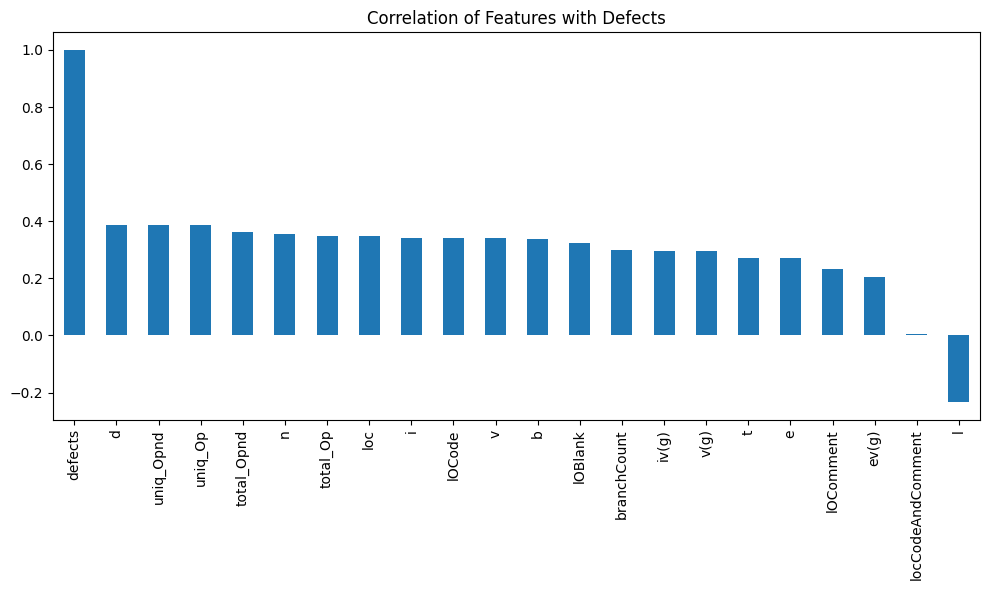

```python
target_corr.plot(kind="bar", figsize=(10,6))

plt.title("Correlation of Features with Defects")
plt.tight_layout()
plt.savefig(os.path.join(output_dir, "target_correlation.png"), dpi=300)
plt.show()
```

```python
target_corr.sort_values(key=abs, ascending=False).head(10)
```

|  | defects |
| --- | --- |
| defects | 1.000000 |
| d | 0.387493 |
| uniq_Opnd | 0.386714 |
| uniq_Op | 0.385566 |
| total_Opnd | 0.362549 |
| n | 0.355101 |
| total_Op | 0.348785 |
| loc | 0.348405 |
| i | 0.342854 |
| lOCode | 0.341529 |

**dtype:** float64

## Data Preprocessing

```python
df["defects"] = df["defects"].astype(int)
```

```python
X = df.drop("defects", axis=1)
y = df["defects"]
```

```python
X_train, X_test, y_train, y_test = train_test_split(
    X,
    y,
    test_size=0.2,
    random_state=42,
    stratify=y
)
```

```python
scaler = StandardScaler()

X_train_scaled = scaler.fit_transform(X_train)
X_test_scaled = scaler.transform(X_test)
```

```python
print("X_Train: ", X_train.shape)
print("X_Test: ", X_test.shape)
print("------------------------------")
print("y_train:",y_train.value_counts())
print("------------------------------")
print("y_test:",y_test.value_counts())
```

```
X_Train:  (1687, 21)
X_Test:  (422, 21)
------------------------------
y_train: defects
0    1426
1     261
Name: count, dtype: int64
------------------------------
y_test: defects
0    357
1     65
Name: count, dtype: int64
```

### Logistic Regression

```python
lr = LogisticRegression(random_state=42)

lr.fit(X_train_scaled, y_train)
```

```
LogisticRegression(random_state=42)
```

```python
y_pred_lr = lr.predict(X_test_scaled)

y_prob_lr = lr.predict_proba(X_test_scaled)[:,1]
```

```python
print("Accuracy :", accuracy_score(y_test, y_pred_lr))
print("Precision:", precision_score(y_test, y_pred_lr))
print("Recall   :", recall_score(y_test, y_pred_lr))
print("F1 Score :", f1_score(y_test, y_pred_lr))
print("ROC AUC  :", roc_auc_score(y_test, y_prob_lr))
```

```
Accuracy : 0.8601895734597157
Precision: 0.6363636363636364
Recall   : 0.2153846153846154
F1 Score : 0.3218390804597701
ROC AUC  : 0.8040077569489334
```

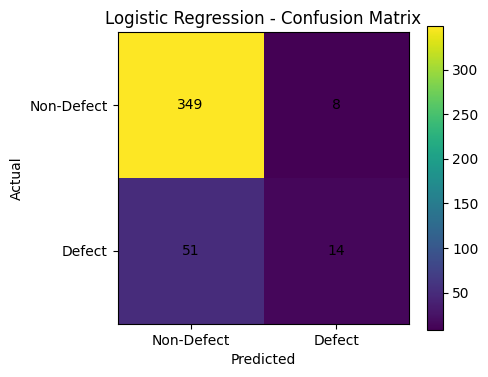

```python
cm = confusion_matrix(y_test, y_pred_lr)

plt.figure(figsize=(5,4))
plt.imshow(cm)

plt.title("Logistic Regression - Confusion Matrix")
plt.colorbar()

plt.xticks([0,1],["Non-Defect","Defect"])
plt.yticks([0,1],["Non-Defect","Defect"])

plt.xlabel("Predicted")
plt.ylabel("Actual")

for i in range(2):
    for j in range(2):
        plt.text(j, i, cm[i,j], ha="center", va="center")

plt.tight_layout()
plt.savefig(os.path.join(output_dir, "lr_confusion_matrix.png"), dpi=300)
plt.show()
```

#### ROC Curve

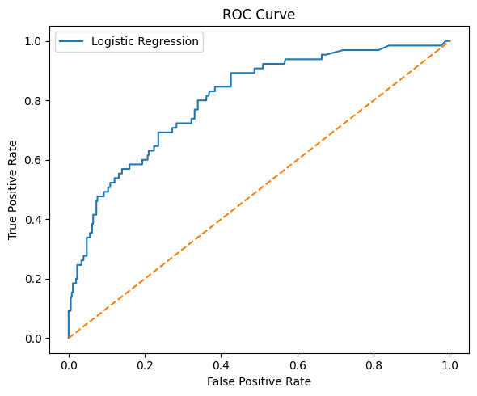

```python
fpr, tpr, _ = roc_curve(y_test, y_prob_lr)

plt.figure(figsize=(6,5))
plt.plot(fpr, tpr, label="Logistic Regression")
plt.plot([0,1],[0,1],'--')

plt.xlabel("False Positive Rate")
plt.ylabel("True Positive Rate")
plt.title("ROC Curve")

plt.legend()

plt.tight_layout()
plt.savefig(os.path.join(output_dir, "lr_roc_curve.png"), dpi=300)
plt.show()
```

#### Observation:

- High accuracy but low recall.
- The model misses many defective modules, so there is room for improvement with Random Forest, XGBoost, and later SMOTE.

### Random Forest

```python
rf = RandomForestClassifier(
    n_estimators=100,
    random_state=42
)

rf.fit(X_train, y_train)
```

```
RandomForestClassifier(random_state=42)
```

```python
y_pred_rf = rf.predict(X_test)
y_prob_rf = rf.predict_proba(X_test)[:,1]
```

```python
print("Accuracy :", accuracy_score(y_test, y_pred_rf))
print("Precision:", precision_score(y_test, y_pred_rf))
print("Recall   :", recall_score(y_test, y_pred_rf))
print("F1 Score :", f1_score(y_test, y_pred_rf))
print("ROC AUC  :", roc_auc_score(y_test, y_prob_rf))
```

```
Accuracy : 0.8578199052132701
Precision: 0.5555555555555556
Recall   : 0.38461538461538464
F1 Score : 0.45454545454545453
ROC AUC  : 0.8334195216548158
```

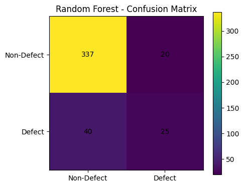

```python
cm = confusion_matrix(y_test, y_pred_rf)

plt.figure(figsize=(5,4))
plt.imshow(cm)
plt.title("Random Forest - Confusion Matrix")
plt.colorbar()

plt.xticks([0,1],["Non-Defect","Defect"])
plt.yticks([0,1],["Non-Defect","Defect"])

for i in range(2):
    for j in range(2):
        plt.text(j, i, cm[i,j], ha="center", va="center")

plt.tight_layout()
plt.savefig(os.path.join(output_dir, "rf_confusion_matrix.png"), dpi=300)
plt.show()
```

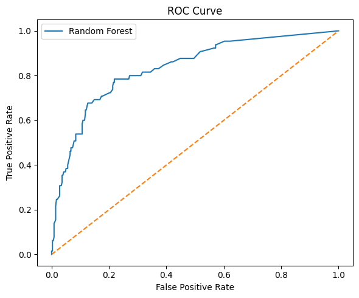

```python
fpr, tpr, _ = roc_curve(y_test, y_prob_rf)

plt.figure(figsize=(6,5))
plt.plot(fpr, tpr, label="Random Forest")
plt.plot([0,1],[0,1],"--")

plt.xlabel("False Positive Rate")
plt.ylabel("True Positive Rate")
plt.title("ROC Curve")
plt.legend()

plt.tight_layout()
plt.savefig(os.path.join(output_dir, "rf_roc_curve.png"), dpi=300)
plt.show()
```

### XGBoost

```python
xgb = XGBClassifier(
    random_state=42,
    eval_metric="logloss"
)

xgb.fit(X_train, y_train)
```

```
XGBClassifier(base_score=None, booster=None, callbacks=None,
              colsample_bylevel=None, colsample_bynode=None,
              colsample_bytree=None, device=None, early_stopping_rounds=None,
              enable_categorical=True, eval_metric='logloss',
              feature_types=None, feature_weights=None, gamma=None,
              grow_policy=None, importance_type=None,
              interaction_constraints=None, learning_rate=None, max_bin=None,
              max_cat_threshold=None, max_cat_to_onehot=None,
              max_delta_step=None, max_depth=None, max_leaves=None,
              min_child_weight=None, missing=nan, monotone_constraints=None,
              multi_strategy=None, n_estimators=None, n_jobs=None,
              num_parallel_tree=None, ...)
```

```python
y_pred_xgb = xgb.predict(X_test)
y_prob_xgb = xgb.predict_proba(X_test)[:,1]
```

```python
print("Accuracy :", accuracy_score(y_test, y_pred_xgb))
print("Precision:", precision_score(y_test, y_pred_xgb))
print("Recall   :", recall_score(y_test, y_pred_xgb))
print("F1 Score :", f1_score(y_test, y_pred_xgb))
print("ROC AUC  :", roc_auc_score(y_test, y_prob_xgb))
```

```
Accuracy : 0.8649289099526066
Precision: 0.5869565217391305
Recall   : 0.4153846153846154
F1 Score : 0.4864864864864865
ROC AUC  : 0.8279681103210514
```

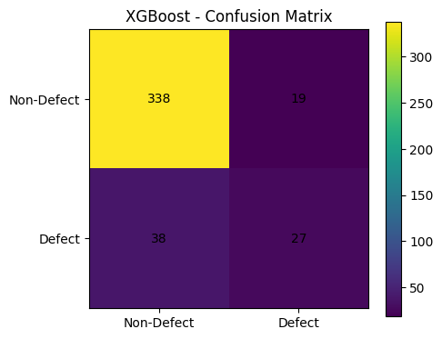

```python
cm = confusion_matrix(y_test, y_pred_xgb)

plt.figure(figsize=(5,4))
plt.imshow(cm)
plt.title("XGBoost - Confusion Matrix")
plt.colorbar()

plt.xticks([0,1],["Non-Defect","Defect"])
plt.yticks([0,1],["Non-Defect","Defect"])

for i in range(2):
    for j in range(2):
        plt.text(j, i, cm[i,j], ha="center", va="center")

plt.tight_layout()
plt.savefig(os.path.join(output_dir, "xgb_confusion_matrix.png"), dpi=300)
plt.show()
```

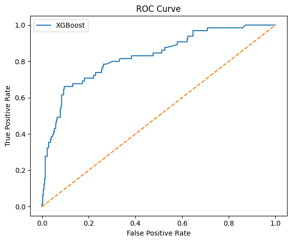

```python
fpr, tpr, _ = roc_curve(y_test, y_prob_xgb)

plt.figure(figsize=(6,5))
plt.plot(fpr, tpr, label="XGBoost")
plt.plot([0,1],[0,1],"--")

plt.xlabel("False Positive Rate")
plt.ylabel("True Positive Rate")
plt.title("ROC Curve")
plt.legend()

plt.tight_layout()
plt.savefig(os.path.join(output_dir, "xgb_roc_curve.png"), dpi=300)
plt.show()
```

#### Observation

- XGBoost achieved the highest Accuracy, Recall, and F1-score, indicating the best overall defect prediction performance.
- Random Forest achieved the highest ROC-AUC, suggesting strong discriminative ability.
- Logistic Regression had the highest Precision, but its low Recall means it missed many defective modules.

```python
results = pd.DataFrame({
    "Model": ["Logistic Regression", "Random Forest", "XGBoost"],
    "Accuracy": [
        accuracy_score(y_test, y_pred_lr),
        accuracy_score(y_test, y_pred_rf),
        accuracy_score(y_test, y_pred_xgb)
    ],
    "Precision": [
        precision_score(y_test, y_pred_lr),
        precision_score(y_test, y_pred_rf),
        precision_score(y_test, y_pred_xgb)
    ],
    "Recall": [
        recall_score(y_test, y_pred_lr),
        recall_score(y_test, y_pred_rf),
        recall_score(y_test, y_pred_xgb)
    ],
    "F1-Score": [
        f1_score(y_test, y_pred_lr),
        f1_score(y_test, y_pred_rf),
        f1_score(y_test, y_pred_xgb)
    ],
    "ROC-AUC": [
        roc_auc_score(y_test, y_prob_lr),
        roc_auc_score(y_test, y_prob_rf),
        roc_auc_score(y_test, y_prob_xgb)
    ]
})

results = results.round(4)
results
```

|  | Model | Accuracy | Precision | Recall | F1-Score | ROC-AUC |
| --- | --- | --- | --- | --- | --- | --- |
| 0 | Logistic Regression | 0.8602 | 0.6364 | 0.2154 | 0.3218 | 0.8040 |
| 1 | Random Forest | 0.8578 | 0.5556 | 0.3846 | 0.4545 | 0.8334 |
| 2 | XGBoost | 0.8649 | 0.5870 | 0.4154 | 0.4865 | 0.8280 |

```python
results.to_csv("/content/drive/MyDrive/MS in AL ML Walsh/Capstone/Tables/model_comparison.csv", index=False)
```

### SMOTE

```python
smote = SMOTE(random_state=42)

X_train_smote, y_train_smote = smote.fit_resample(X_train, y_train)

print(y_train.value_counts())
print(y_train_smote.value_counts())
```

```
defects
0    1426
1     261
Name: count, dtype: int64
defects
0    1426
1    1426
Name: count, dtype: int64
```

#### Train XGBoost on SMOTE Data

```python
xgb_smote = XGBClassifier(
    random_state=42,
    eval_metric="logloss"
)

xgb_smote.fit(X_train_smote, y_train_smote)
```

```
XGBClassifier(base_score=None, booster=None, callbacks=None,
              colsample_bylevel=None, colsample_bynode=None,
              colsample_bytree=None, device=None, early_stopping_rounds=None,
              enable_categorical=True, eval_metric='logloss',
              feature_types=None, feature_weights=None, gamma=None,
              grow_policy=None, importance_type=None,
              interaction_constraints=None, learning_rate=None, max_bin=None,
              max_cat_threshold=None, max_cat_to_onehot=None,
              max_delta_step=None, max_depth=None, max_leaves=None,
              min_child_weight=None, missing=nan, monotone_constraints=None,
              multi_strategy=None, n_estimators=None, n_jobs=None,
              num_parallel_tree=None, ...)
```

```python
y_pred_smote = xgb_smote.predict(X_test)
y_prob_smote = xgb_smote.predict_proba(X_test)[:,1]

print("Accuracy :", accuracy_score(y_test, y_pred_smote))
print("Precision:", precision_score(y_test, y_pred_smote))
print("Recall   :", recall_score(y_test, y_pred_smote))
print("F1 Score :", f1_score(y_test, y_pred_smote))
print("ROC AUC  :", roc_auc_score(y_test, y_prob_smote))
```

```
Accuracy : 0.8649289099526066
Precision: 0.5666666666666667
Recall   : 0.5230769230769231
F1 Score : 0.544
ROC AUC  : 0.8225382460676578
```

### SHAP

```python
explainer = shap.TreeExplainer(xgb_smote)
```

```python
shap_values = explainer.shap_values(X_test)
```

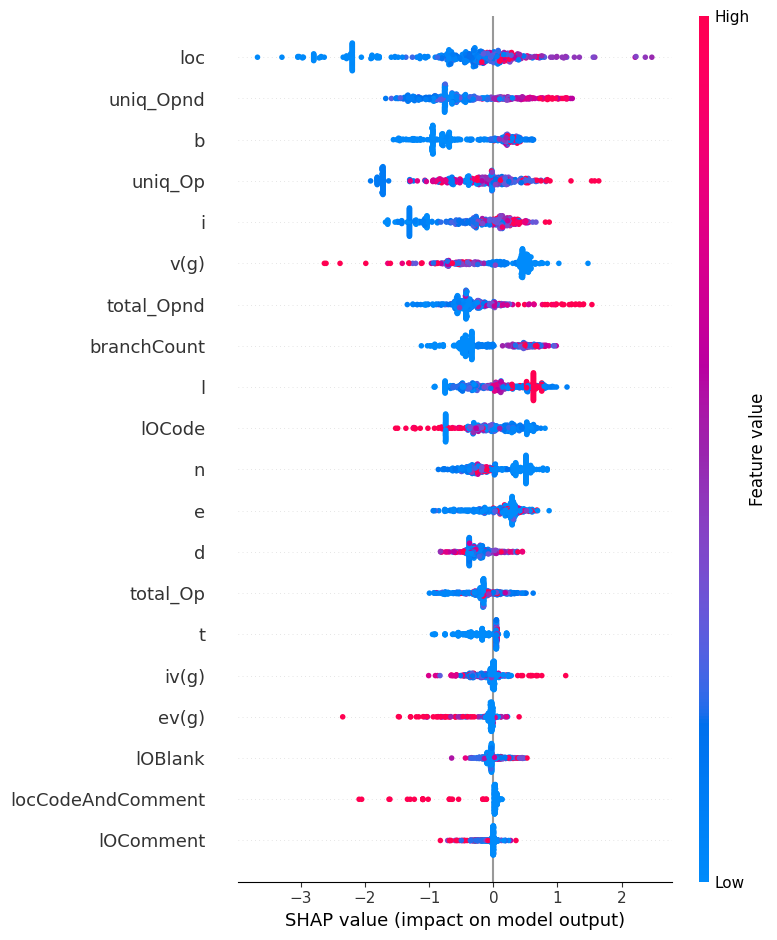

```python
shap.summary_plot(
    shap_values,
    X_test,
    feature_names=X.columns,
    show=False
)

plt.tight_layout()
plt.savefig(os.path.join(output_dir, "shap_summary.png"), dpi=300)
plt.show()
```

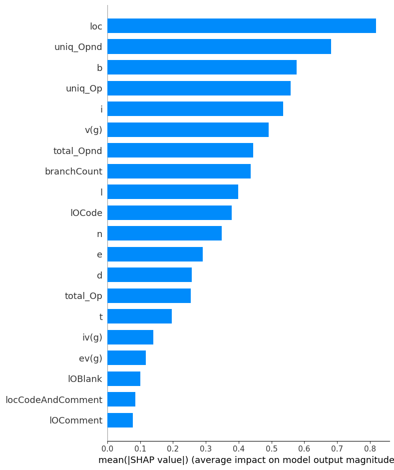

```python
shap.summary_plot(
    shap_values,
    X_test,
    feature_names=X.columns,
    plot_type="bar",
    show=False
)

plt.tight_layout()
plt.savefig(os.path.join(output_dir, "shap_bar.png"), dpi=300)
plt.show()
```

```python
importance = pd.DataFrame({
    "Feature": X.columns,
    "Importance": np.abs(shap_values).mean(axis=0)
})

importance = importance.sort_values(
    by="Importance",
    ascending=False
)

importance.head(10)
```

|  | Feature | Importance |
| --- | --- | --- |
| 0 | loc | 0.818608 |
| 17 | uniq_Opnd | 0.681912 |
| 10 | b | 0.577102 |
| 16 | uniq_Op | 0.558988 |
| 8 | i | 0.535609 |
| 1 | v(g) | 0.491362 |
| 19 | total_Opnd | 0.444124 |
| 20 | branchCount | 0.437448 |
| 6 | l | 0.399323 |
| 12 | lOCode | 0.378979 |

```python
importance.head(10).to_csv(
    "/content/drive/MyDrive/MS in AL ML Walsh/Capstone/Tables/shap_feature_importance.csv",
    index=False
)
```

### All Models comparison

```python
results = pd.DataFrame({
    "Model": ["Logistic Regression", "Random Forest", "XGBoost","XGBoostSMOTE"],
    "Accuracy": [
        accuracy_score(y_test, y_pred_lr),
        accuracy_score(y_test, y_pred_rf),
        accuracy_score(y_test, y_pred_xgb),
        accuracy_score(y_test, y_pred_smote)
    ],
    "Precision": [
        precision_score(y_test, y_pred_lr),
        precision_score(y_test, y_pred_rf),
        precision_score(y_test, y_pred_xgb),
        precision_score(y_test, y_pred_smote)
    ],
    "Recall": [
        recall_score(y_test, y_pred_lr),
        recall_score(y_test, y_pred_rf),
        recall_score(y_test, y_pred_xgb),
        recall_score(y_test, y_pred_smote)
    ],
    "F1-Score": [
        f1_score(y_test, y_pred_lr),
        f1_score(y_test, y_pred_rf),
        f1_score(y_test, y_pred_xgb),
        f1_score(y_test, y_pred_smote)
    ],
    "ROC-AUC": [
        roc_auc_score(y_test, y_prob_lr),
        roc_auc_score(y_test, y_prob_rf),
        roc_auc_score(y_test, y_prob_xgb),
         roc_auc_score(y_test, y_prob_smote)
    ]
})

results = results.round(4)
results
```

|  | Model | Accuracy | Precision | Recall | F1-Score | ROC-AUC |
| --- | --- | --- | --- | --- | --- | --- |
| 0 | Logistic Regression | 0.8602 | 0.6364 | 0.2154 | 0.3218 | 0.8040 |
| 1 | Random Forest | 0.8578 | 0.5556 | 0.3846 | 0.4545 | 0.8334 |
| 2 | XGBoost | 0.8649 | 0.5870 | 0.4154 | 0.4865 | 0.8280 |
| 3 | XGBoostSMOTE | 0.8649 | 0.5667 | 0.5231 | 0.5440 | 0.8225 |

```python
df.to_csv("/content/drive/MyDrive/MS in AL ML Walsh/Capstone/Tables/cleaned_dataset.csv", index=False)
```